# Week 8

# color maps

```python
import matplotlib.cm as cm
import matplotlib.pyplot as plt
import numpy as np
```

```python
dir(cm)
```

```
['Accent',
 'Accent_r',
 'Blues',
 'Blues_r',
 'BrBG',
 'BrBG_r',
 'BuGn',
 'BuGn_r',
 'BuPu',
 'BuPu_r',
 'CMRmap',
 'CMRmap_r',
 'Dark2',
 'Dark2_r',
 'GnBu',
 'GnBu_r',
 'Greens',
 'Greens_r',
 'Greys',
 'Greys_r',
 'LUTSIZE',
 'OrRd',
 'OrRd_r',
 'Oranges',
 'Oranges_r',
 'PRGn',
 'PRGn_r',
 'Paired',
 'Paired_r',
 'Pastel1',
 'Pastel1_r',
 'Pastel2',
 'Pastel2_r',
 'PiYG',
 'PiYG_r',
 'PuBu',
 'PuBuGn',
 'PuBuGn_r',
 'PuBu_r',
 'PuOr',
```

[output cut: 135 more lines]

```
 'tab20_r',
 'tab20b',
 'tab20b_r',
 'tab20c',
 'tab20c_r',
 'terrain',
 'terrain_r',
 'twilight',
 'twilight_r',
 'twilight_shifted',
 'twilight_shifted_r',
 'viridis',
 'viridis_r',
 'winter',
 'winter_r']
```

colormaps are set of colors, that can be selected assigning a value in [0,1)

```python
cm.Reds(0.5)
```

```
(0.9835755478662053, 0.4127950788158401, 0.28835063437139563, 1.0)
```

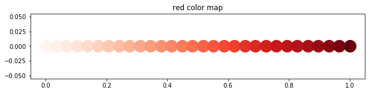

```python
x=np.linspace(0,1,30)

plt.figure(figsize=(10,2))
for t in x:
    plt.plot(t,0,'o',ms=20,color=cm.Reds(t))
plt.title('red color map')
plt.show()
```

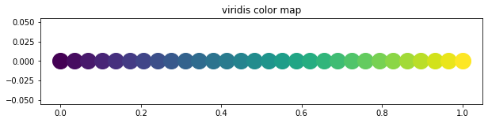

```python
x=np.linspace(0,1,30)

plt.figure(figsize=(10,2))
for t in x:
    plt.plot(t,0,'o',ms=20,color=cm.viridis(t))
plt.title('viridis color map')
plt.show()
```

**Ex.** create a 2x2 plot of a gradient of colormaps, with the 4 seasons. With title **Seasons, by First Last**. Post this on discord channel **seasons**

autumn, summer,spring, winter colormaps

# RGB colors

RGB (Red-Green-Blue), 1 full color, 0 no color

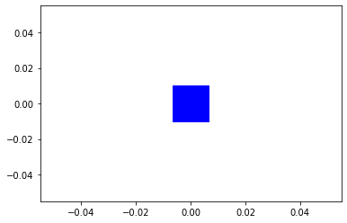

```python
plt.plot(0,0,'s',ms=40,color=(0,0,1))
plt.show()
```

To make other colors we need to mix RGB

```
(-0.1, 1.1)
```

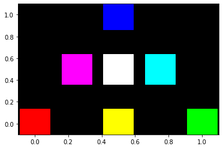

```python
ax=plt.subplot(111)
plt.plot(0,0,'s',ms=50,color=(1,0,0)) #red
plt.plot(1,0,'s',ms=50,color=(0,1,0)) #green
plt.plot(0.5,1,'s',ms=50,color=(0,0,1)) #blue
plt.plot(0.25,0.5,'s',ms=50,color=(1,0,1)) # red+ blue = magenta
plt.plot(0.75,0.5,'s',ms=50,color=(0,1,1)) # green + clue = cyan
plt.plot(0.5,0,'s',ms=50,color=(1,1,0)) # red + green = yellow
plt.plot(0.5,0.5,'s',ms=50,color=(1,1,1)) # red + green + blue = white
ax.set_facecolor((0,0,0))# black background
plt.xlim(-0.1,1.1)
plt.ylim(-0.1,1.1)
#plt.axis('equal')
```

# Multidimensional array

Arrays can have more than one dimension

How do we create them? One way is to start from 1-d array and then `reshape` it

```python
a=np.linspace(1,12,12)
print(a)
```

```
[ 1.  2.  3.  4.  5.  6.  7.  8.  9. 10. 11. 12.]
```

```python
b=a.reshape(3,4)
print(b)
```

```
[[ 1.  2.  3.  4.]
 [ 5.  6.  7.  8.]
 [ 9. 10. 11. 12.]]
```

```python
b=a.reshape(6,-1) # a -1 as a dimension , means thay python will authomatically find the correct dimension
print(b)
```

```
[[ 1.  2.]
 [ 3.  4.]
 [ 5.  6.]
 [ 7.  8.]
 [ 9. 10.]
 [11. 12.]]
```

```python
c=a.reshape(-1,3) # a -1 as a dimension , means thay python will authomatically find the correct dimension
print(b)
```

```
[[ 1.  2.]
 [ 3.  4.]
 [ 5.  6.]
 [ 7.  8.]
 [ 9. 10.]
 [11. 12.]]
```

```python
a.shape
```

```
(12,)
```

```python
b.shape
```

```
(6, 2)
```

```python
c.shape
```

```
(4, 3)
```

```python
c.shape[0] # number of rows
```

```
4
```

```python
print(a,'\n\n',b,'\n\n',c)
```

```
[ 1.  2.  3.  4.  5.  6.  7.  8.  9. 10. 11. 12.]

 [[ 1.  2.]
 [ 3.  4.]
 [ 5.  6.]
 [ 7.  8.]
 [ 9. 10.]
 [11. 12.]]

 [[ 1.  2.  3.]
 [ 4.  5.  6.]
 [ 7.  8.  9.]
 [10. 11. 12.]]
```

```python
a[2]=13
print(a,'\n\n',b,'\n\n',c)
```

```
[ 1.  2. 13.  4.  5.  6.  7.  8.  9. 10. 11. 12.]

 [[ 1.  2.]
 [13.  4.]
 [ 5.  6.]
 [ 7.  8.]
 [ 9. 10.]
 [11. 12.]]

 [[ 1.  2. 13.]
 [ 4.  5.  6.]
 [ 7.  8.  9.]
 [10. 11. 12.]]
```

`reshape` produces a view of the object, **NOT** a copy

```python
d=a.reshape(3,-1).copy()
```

```python
a
```

```
array([ 1.,  2., 13.,  4.,  5.,  6.,  7.,  8.,  9., 10., 11., 12.])
```

```python
d
```

```
array([[ 1.,  2., 13.,  4.],
       [ 5.,  6.,  7.,  8.],
       [ 9., 10., 11., 12.]])
```

```python
a[4]=123
```

```python
print(a,d)
```

```
[  1.   2.  13.   4. 123.   6.   7.   8.   9.  10.  11.  12.] [[ 1.  2. 13.  4.]
 [ 5.  6.  7.  8.]
 [ 9. 10. 11. 12.]]
```

```python
b.shape
```

```
(6, 2)
```

How do we access elements of a multidimensional array?

```python
b
```

```
array([[  1.,   2.],
       [ 13.,   4.],
       [123.,   6.],
       [  7.,   8.],
       [  9.,  10.],
       [ 11.,  12.]])
```

```python
b[4,1]
```

```
10.0
```

```python
b[4,1]=100
print(b)
```

```
[[  1.   2.]
 [ 13.   4.]
 [123.   6.]
 [  7.   8.]
 [  9. 100.]
 [ 11.  12.]]
```

```python
print(a)
```

```
[  1.   2.  13.   4. 123.   6.   7.   8.   9. 100.  11.  12.]
```

```python
b[4][1]
```

```
100.0
```

```python
b[2,:] # to access a specific row
```

```
array([123.,   6.])
```

```python
b[2]
```

```
array([123.,   6.])
```

```python
b[:,1] # to get a column
```

```
array([  2.,   4.,   6.,   8., 100.,  12.])
```

`np.ones`, `np.empty`, `np.zeros` work for multidimensional arrays as well

```python
e=np.ones((5,7))
print(e)
```

```
[[1. 1. 1. 1. 1. 1. 1.]
 [1. 1. 1. 1. 1. 1. 1.]
 [1. 1. 1. 1. 1. 1. 1.]
 [1. 1. 1. 1. 1. 1. 1.]
 [1. 1. 1. 1. 1. 1. 1.]]
```

## Operations

```python
a=np.arange(15).reshape(3,5)
b=np.arange(2,17).reshape(3,5)

print(a)
print(b)
```

```
[[ 0  1  2  3  4]
 [ 5  6  7  8  9]
 [10 11 12 13 14]]
[[ 2  3  4  5  6]
 [ 7  8  9 10 11]
 [12 13 14 15 16]]
```

```python
c=a+b
print(c)
```

```
[[ 2  4  6  8 10]
 [12 14 16 18 20]
 [22 24 26 28 30]]
```

```python
print(2*a*b) # element by element multiplication
```

```
[[  0   6  16  30  48]
 [ 70  96 126 160 198]
 [240 286 336 390 448]]
```

`@` or `dot()` to do matrix multiplication (as seen in linear algebra)

```python
a@b.transpose() # a is 3x5, b^T is 5x3
```

```
array([[ 50, 100, 150],
       [150, 325, 500],
       [250, 550, 850]])
```

```python
a.dot(b.transpose())
```

```
array([[ 50, 100, 150],
       [150, 325, 500],
       [250, 550, 850]])
```

```python
np.log(c)
```

```
array([[0.69314718, 1.38629436, 1.79175947, 2.07944154, 2.30258509],
       [2.48490665, 2.63905733, 2.77258872, 2.89037176, 2.99573227],
       [3.09104245, 3.17805383, 3.25809654, 3.33220451, 3.40119738]])
```

```python
a@b
```

```
---------------------------------------------------------------------------
ValueError                                Traceback (most recent call last)
<ipython-input-47-a832bb91e25d> in <module>
----> 1 a@b

ValueError: matmul: Input operand 1 has a mismatch in its core dimension 0, with gufunc signature (n?,k),(k,m?)->(n?,m?) (size 3 is different from 5)
```

## Slicing

```python
x=np.arange(40).reshape(5,8)
print(x)
```

```
[[ 0  1  2  3  4  5  6  7]
 [ 8  9 10 11 12 13 14 15]
 [16 17 18 19 20 21 22 23]
 [24 25 26 27 28 29 30 31]
 [32 33 34 35 36 37 38 39]]
```

```python
x[1:4,2:5]
```

```
array([[10, 11, 12],
       [18, 19, 20],
       [26, 27, 28]])
```

```python
x[1:3,::2]
```

```
array([[ 8, 10, 12, 14],
       [16, 18, 20, 22]])
```

```python
x[0,:]=np.ones(8)
```

```python
x
```

```
array([[ 1,  1,  1,  1,  1,  1,  1,  1],
       [ 8,  9, 10, 11, 12, 13, 14, 15],
       [16, 17, 18, 19, 20, 21, 22, 23],
       [24, 25, 26, 27, 28, 29, 30, 31],
       [32, 33, 34, 35, 36, 37, 38, 39]])
```

You can assign a single value at once

```python
x[2,:]=33
print(x)
```

```
[[ 1  1  1  1  1  1  1  1]
 [ 8  9 10 11 12 13 14 15]
 [33 33 33 33 33 33 33 33]
 [24 25 26 27 28 29 30 31]
 [32 33 34 35 36 37 38 39]]
```

```python
x[2:4,2:5]=0
x
```

```
array([[ 1,  1,  1,  1,  1,  1,  1,  1],
       [ 8,  9, 10, 11, 12, 13, 14, 15],
       [33, 33,  0,  0,  0, 33, 33, 33],
       [24, 25,  0,  0,  0, 29, 30, 31],
       [32, 33, 34, 35, 36, 37, 38, 39]])
```

```python
x[2:4,3:6]=np.linspace(101,107,6).reshape(2,3) # we assigned one array to a sub-array
x
```

```
array([[  1,   1,   1,   1,   1,   1,   1,   1],
       [  8,   9,  10,  11,  12,  13,  14,  15],
       [ 33,  33,   0, 101, 102, 103,  33,  33],
       [ 24,  25,   0, 104, 105, 107,  30,  31],
       [ 32,  33,  34,  35,  36,  37,  38,  39]])
```

```python
w=x.ravel()
print(w)
```

```
[  1   1   1   1   1   1   1   1   8   9  10  11  12  13  14  15  33  33
   0 101 102 103  33  33  24  25   0 104 105 107  30  31  32  33  34  35
  36  37  38  39]
```

## `imshow`

```python
a=np.random.rand(3,3)
print(a)
```

```
[[0.71494533 0.64926852 0.87332416]
 [0.37446117 0.52843786 0.55075167]
 [0.50090672 0.68866338 0.68741616]]
```

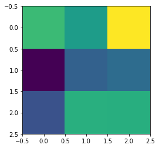

```python
plt.imshow(a)
plt.show()
```

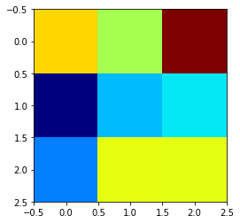

```python
plt.imshow(a,cmap='jet')
```

`plt.imshow()` produces a plot given a multidimensional array. (pixel by pixel)

```python
a.shape
```

```
(3, 3)
```

## `imshow` `interpolation` parameter

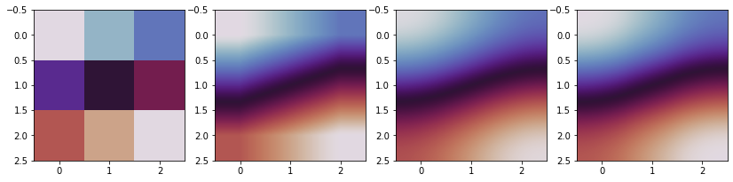

```python
plt.figure(figsize=(14,8))

a=np.linspace(0,1,9).reshape(3,3)

plt.subplot(141)
plt.imshow(a,cmap='twilight',interpolation='nearest')

plt.subplot(142)
plt.imshow(a,cmap='twilight',interpolation='bilinear')

plt.subplot(143)
plt.imshow(a,cmap='twilight',interpolation='bicubic')

plt.subplot(144)
plt.imshow(a,cmap='twilight',interpolation='quadric')

plt.show()
```

## RGB colors

`b` created below contains R, G, B values

- `b[:,:,0]`: contains the value of red
- `b[:,:,1]`: contains the value of green
- `b[:,:,2]`: contains the value of blue

```
[[[0.35412933 0.23949634 0.99862602]
  [0.23490007 0.05171263 0.66702241]
  [0.32103125 0.456564   0.27085988]
  [0.42842589 0.22649253 0.37552856]
  [0.16609196 0.56709871 0.11083436]]

 [[0.02931182 0.83051143 0.53259928]
  [0.59752145 0.97241141 0.02164576]
  [0.49453028 0.71450079 0.8563824 ]
  [0.22580853 0.08467561 0.79998274]
  [0.54087015 0.95378165 0.40702474]]

 [[0.95101781 0.40251177 0.40498606]
  [0.47416662 0.43597934 0.94375349]
  [0.8330774  0.50275858 0.64499201]
  [0.25574332 0.46863328 0.97302351]
  [0.77090849 0.139181   0.65782442]]

 [[0.92452415 0.33309362 0.03592772]
  [0.70951731 0.08896272 0.23501923]
  [0.65129502 0.30540098 0.77294798]
  [0.91288314 0.32202676 0.39196264]
  [0.69134195 0.42819945 0.84246391]]

 [[0.91784132 0.74840423 0.45007444]
  [0.67540415 0.53040518 0.2066348 ]
  [0.61501564 0.20140732 0.20192811]
  [0.00784061 0.81071275 0.23058099]
  [0.17899482 0.98352331 0.61223006]]]
(5, 5, 3)
```

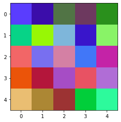

```python
b=np.random.rand(5,5,3)
print(b) # do not rely on what you see here
print(b.shape)
plt.imshow(b)
plt.show()
```

```python
print(b[:,:,0])
```

```
[[0.35412933 0.23490007 0.32103125 0.42842589 0.16609196]
 [0.02931182 0.59752145 0.49453028 0.22580853 0.54087015]
 [0.95101781 0.47416662 0.8330774  0.25574332 0.77090849]
 [0.92452415 0.70951731 0.65129502 0.91288314 0.69134195]
 [0.91784132 0.67540415 0.61501564 0.00784061 0.17899482]]
```

```python
# grab how much blue is in the first pixel
b[0,0,2]
```

```
0.998626018899305
```

**Ex.** given the image above, let's do a 1x4 subplot, with the original image, only red scale, only green scale, only blue scale, Please put your name in the image title

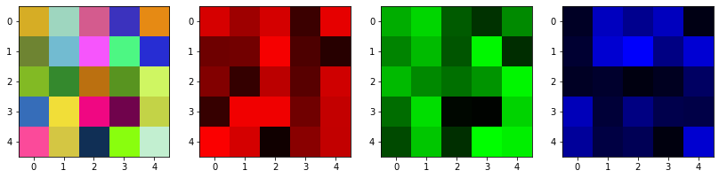

```python
plt.figure(figsize=(14,8))

a=np.random.rand(5,5,3)

plt.subplot(141)
plt.imshow(a)

plt.subplot(142)
r=a.copy()
r[:,:,1]=0 # remove green
r[:,:,2]=0 # remove blue
plt.imshow(r)

plt.subplot(143)
g=a.copy()
g[:,:,0]=0
g[:,:,2]=0
plt.imshow(g)

plt.subplot(144)
b=a.copy()
b[:,:,0]=0
b[:,:,1]=0
plt.imshow(b)

plt.show()
```

**Ex.** repoduce the 4x4 pixels image posted by me in the discord 'colors' channel. Reproduce it and post it in discord. Put you name in the title